# Peek at DSSTox CPC Patent Data

Nyssa Tucker

2023-06-20

# 1 Goal

DSSTox compounds (1e6) mentioned in patent registration scraped into 2 TB of data.

Background:  
- We ran human-patch and guinea pig models against DSSTox and have a subset where the guinea pig skin sensitization model call was negative but where the human-patch assay model call was positive.

- This category of call mismatch is of concern for those protective of human health.
- It may be the case that particular compounds within this category are used in similar products, or if they are used in a fraction of particular products which would frequently come into contact with the skin (i.e., adhesives).

Document Goals:  
1. Annotate smiles with code information.

2. Consider proportion of codes in each classification group (TP/FP/FN/TN)
3. Product categories present in FN group.

This document contains snippet sample. I will practice getting chem annotations using patent info below.

# 2 What we got

Before I start trying to automate the catching of code details using the reference matt shared, I want to peek at the data we get here.

## 2.1 Load & Look

MRH sent a csv snip of the 2TB file for practice.

```r
df <- as_tibble(read_csv("C:/Users/Nyssa/Documents/GitHub/cautious-giggle/mml/20230620_ps_dsstox_cpc_snip.csv"))
#dim(df)

df1 <- df[c(1,2,9,11)]

n_codes <- n_distinct(df1$code)
n_smiles <- n_distinct(df1$smiles)
```

There are 1206 codes in this snip, and 1559 smiles represented.

### 2.1.1 raw data view

Here is the full columns for the file.

```r
head(df)%>%
  kable%>%
  row_spec(0, background = "black")  %>%
  kable_styling("striped", full_width = F) %>%
 scroll_box(width = "500px", height = "200px")
```

| all_assignees | publication_number | all_sources | ocid | preferred_name | domain | inchi | inchi_key | smiles | cpc | code | inventive | first | tree |
| --- | --- | --- | --- | --- | --- | --- | --- | --- | --- | --- | --- | --- | --- |
| MASSACHUSETTS GEN HOSPITAL | US-9889213-B2 | image | 0 | NA | NA | NA | NA | C1NH*I | { “cpc”: [{ “code”: “A61K51/088”, “inventive”: “true”, “first”: “true”, “tree”: [] }, { “code”: “A61K49/0041”, “inventive”: “true”, “first”: “false”, “tree”: [] }, { “code”: “A61K49/14”, “inventive”: … | A61K51/088 | TRUE | TRUE | [] |
| MASSACHUSETTS GEN HOSPITAL | US-9889213-B2 | image | 0 | NA | NA | NA | NA | C1NH*I | { “cpc”: [{ “code”: “A61K51/088”, “inventive”: “true”, “first”: “true”, “tree”: [] }, { “code”: “A61K49/0041”, “inventive”: “true”, “first”: “false”, “tree”: [] }, { “code”: “A61K49/14”, “inventive”: … | A61K51/088 | TRUE | TRUE | [] |
| EBARA CORP | CN-1215592-C | pdf | 0 | NA | NA | NA | NA | CC1([C]2(=CC(C)(CC2)C)*)CC2=CC1 | { “cpc”: [{ “code”: “Y02E60/50”, “inventive”: “false”, “first”: “false”, “tree”: [] }, { “code”: “C01B3/38”, “inventive”: “true”, “first”: “false”, “tree”: [] }, { “code”: “C01B2203/0233”, “inventive”… | H01M8/0662 | TRUE | TRUE | [] |
| EBARA CORP | CN-1215592-C | pdf | 0 | NA | NA | NA | NA | CC1([C]2(=CC(C)(CC2)C)*)CC2=CC1 | { “cpc”: [{ “code”: “Y02E60/50”, “inventive”: “false”, “first”: “false”, “tree”: [] }, { “code”: “C01B3/38”, “inventive”: “true”, “first”: “false”, “tree”: [] }, { “code”: “C01B2203/0233”, “inventive”… | H01M8/0662 | TRUE | TRUE | [] |
| JANSSEN PHARMACEUTICA NV | AU-2011347377-A1 | pdf | 0 | NA | NA | NA | NA | n1(c(nc(c1*(*)*)**)C#N)* | { “cpc”: [{ “code”: “A61P43/00”, “inventive”: “true”, “first”: “false”, “tree”: [] }, { “code”: “A61P25/16”, “inventive”: “true”, “first”: “false”, “tree”: [] }, { “code”: “A61P25/28”, “inventive”: “t… | C07D487/04 | TRUE | TRUE | [] |
| JANSSEN PHARMACEUTICA NV | AU-2011347377-A1 | pdf | 0 | NA | NA | NA | NA | n1(c(nc(c1*(*)*)**)C#N)* | { “cpc”: [{ “code”: “A61P43/00”, “inventive”: “true”, “first”: “false”, “tree”: [] }, { “code”: “A61P25/16”, “inventive”: “true”, “first”: “false”, “tree”: [] }, { “code”: “A61P25/28”, “inventive”: “t… | C07D487/04 | TRUE | TRUE | [] |

### 2.1.2 raw data view – columns selected

```r
head(df1)%>%
  kable %>%
  row_spec(0, background = "black")  %>%
  kable_styling("striped", full_width = F) %>%
 scroll_box(width = "500px", height = "200px")
```

| all_assignees | publication_number | smiles | code |
| --- | --- | --- | --- |
| MASSACHUSETTS GEN HOSPITAL | US-9889213-B2 | C1NH*I | A61K51/088 |
| MASSACHUSETTS GEN HOSPITAL | US-9889213-B2 | C1NH*I | A61K51/088 |
| EBARA CORP | CN-1215592-C | CC1([C]2(=CC(C)(CC2)C)*)CC2=CC1 | H01M8/0662 |
| EBARA CORP | CN-1215592-C | CC1([C]2(=CC(C)(CC2)C)*)CC2=CC1 | H01M8/0662 |
| JANSSEN PHARMACEUTICA NV | AU-2011347377-A1 | n1(c(nc(c1*(*)*)**)C#N)* | C07D487/04 |
| JANSSEN PHARMACEUTICA NV | AU-2011347377-A1 | n1(c(nc(c1*(*)*)**)C#N)* | C07D487/04 |

## 2.2 How many times does a given patent code appear?

```r
tab <- as_tibble(as.data.frame(table(df1$code)))

tab <- tab %>% filter(Freq >= 1)

tab <- tab %>% arrange(-Freq)
colnames(tab) <- c("code","Freq")
```

### 2.2.1 code appearance table

```r
kable(head(tab))
```

| code | Freq |
| --- | --- |
| C07D471/04 | 138 |
| C07D487/04 | 117 |
| C07D401/14 | 60 |
| C07D401/12 | 37 |
| C07D401/04 | 30 |
| A61K31/506 | 29 |

### 2.2.2 code appearance histogram

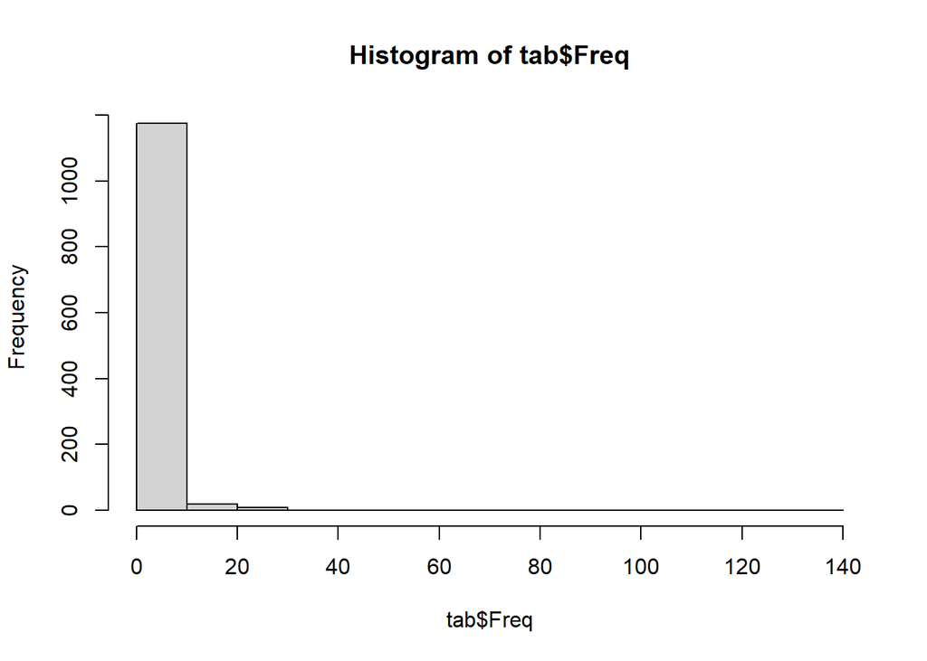

```r
hist(tab$Freq)
```

## 2.3 In this sample, how many codes per included smiles?

```r
tab <- as_tibble(as.data.frame(table(df1$smiles)))

tab <- tab %>% filter(Freq >= 1)

tab <- tab %>% arrange(-Freq)
colnames(tab) <- c("SMILES","Freq")
```

### 2.3.1 codes/smiles histogram

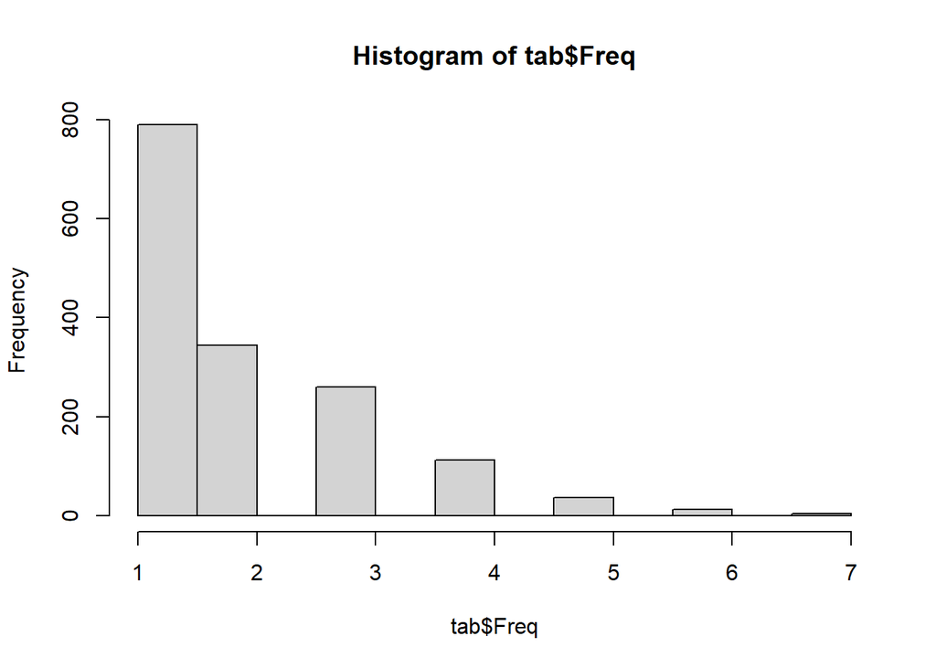

```r
hist(tab$Freq)
```

### 2.3.2 codes/smiles table

```r
kable(head(tab))
```

| SMILES | Freq |
| --- | --- |
| *CCC1C*1N(C*CC)C | 7 |
| c1c(cc(c(c1)CNC1=N/C(=C/N=C(/C2=C(C=C=CN=C2C)C2CC2))/C(=*=C)N(C1=O)C@@HC1CC1)OC)C#N | 7 |
| C1CC@@HNC(=O)C | 7 |
| CCCC[I]1CC[IH]CC1 | 7 |
| *(=C)c1ccc(n2c(=O)c3c(c(c2)c2cnn(c2)C)ccn3[Fl])cc1 | 6 |
| *(CCN(c1cc(O*)c(Nc2nc(c3c4ccccc4n(c3)C)c(cn2)N(C)C(=C)C(C)C)cc1N)C)(*)* | 6 |

## 2.4 max per smiles code

```r
tab <- as_tibble(as.data.frame(table(df1$smiles,df1$code)))

tab <- tab %>% filter(Freq >= 1)

tab <- tab %>% arrange(-Freq)
colnames(tab) <- c("SMILES","code","Freq")
```

### 2.4.1 code*smiles table

```r
kable(head(tab[c("code","Freq")]))
```

| code | Freq |
| --- | --- |
| C07D471/14 | 6 |
| A61K47/6803 | 5 |
| C07D211/76 | 5 |
| C07D417/14 | 5 |
| C07D471/04 | 5 |
| C07D471/04 | 5 |

# 3 What gotta do

## 3.1 API code info automate

I think the best way to do this may be to grep out parts of the code, first letter etc, and aggregate first that way.

```r
df2 <- df1[c("smiles","code")]

df2$code1 <- df2$code %>%substr(1, 1)
df2$code2 <- df2$code %>%substr(2, 2)
df2$code3 <- df2$code %>%substr(3, 3)
df2$code4 <- df2$code %>%substr(4, 4)
df2$code5 <- df2$code %>%substr(5, 5)
df2$code6 <- df2$code %>%substr(6, 6)
df2$code7 <- df2$code %>%substr(7, 7)
df2$code8 <- df2$code %>%substr(8, 8)
df2$code9 <- df2$code %>%substr(9, 9)
df2$code10 <- df2$code %>%substr(10, 10)
df2$code11 <- df2$code %>%substr(11, 11)
df2$code12 <- df2$code %>%substr(12, 12)
df2$code13 <- df2$code %>%substr(13, 13)
df2$code_n <- nchar(df2$code)
max_code_n <- max(nchar(df2$code))
```

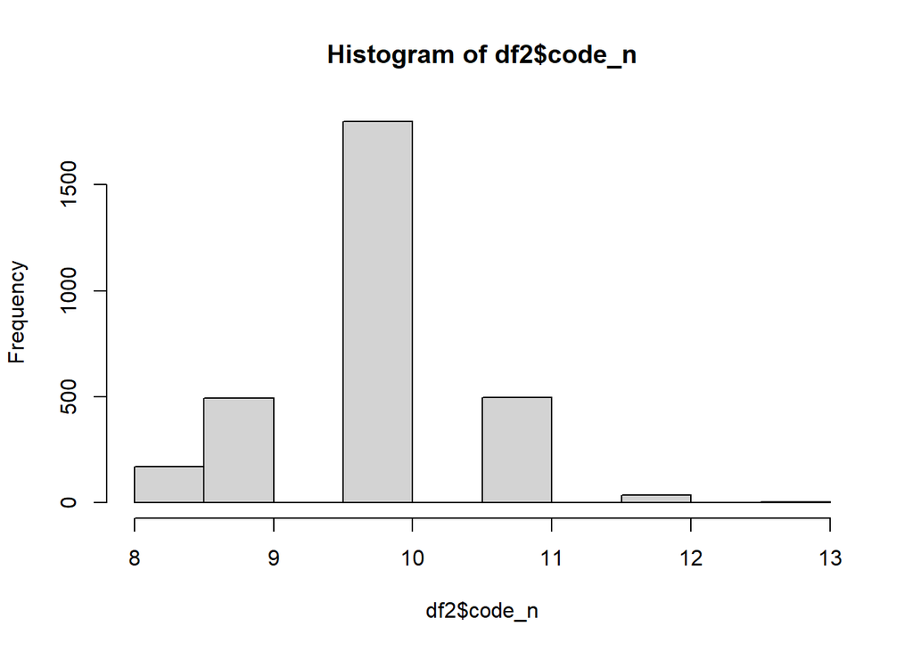

```r
hist(df2$code_n)
```

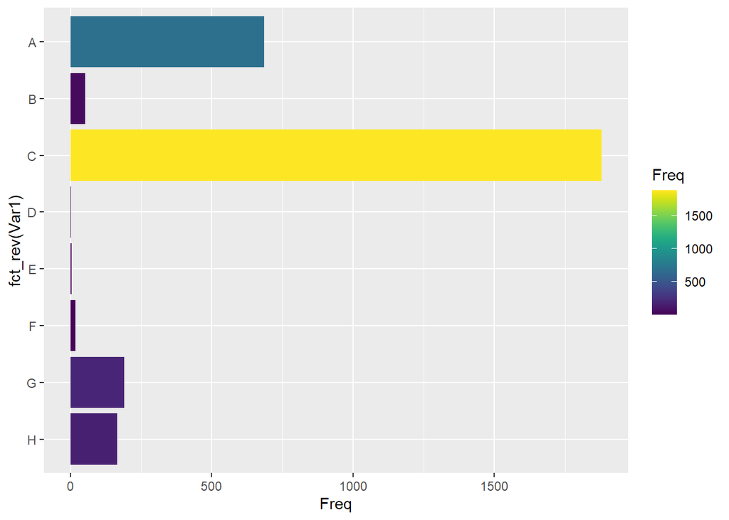

```r
tab <- as_tibble(as.data.frame(table(df2$code1)))

tab <-tab %>% filter(Freq >= 1)


tab %>% ggplot(aes(fct_rev(Var1),Freq,fill = Freq)) +
  geom_col() +
  coord_flip() +
  scale_fill_viridis()
```

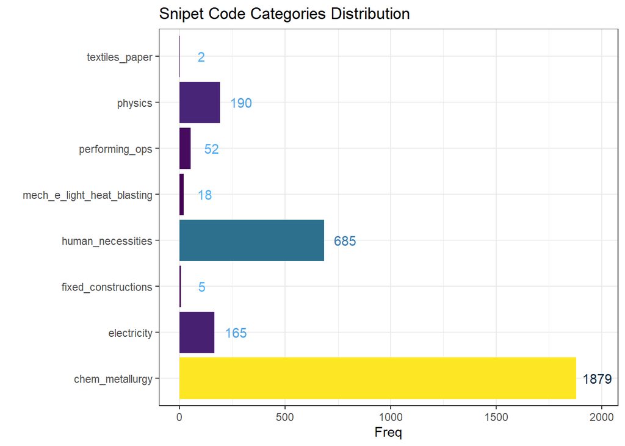

```r
df_a <- as_tibble(read_csv("C:/Users/Nyssa/Documents/GitHub/cautious-giggle/mml/20230620_mml_ps_cpc_codes.csv"))
#dim(df)
tab2 <- tab %>% merge(df_a[c("label","title")],
                      by.x = "Var1",
                      by.y = "label")
#
# tab2 %>% ggplot(aes(fct_rev(Var1),Freq,fill = Freq,
#                     label = title)) +
#   geom_col() +
#   coord_flip() +
#   geom_text() +
#   scale_fill_viridis()


tab2 %>% ggplot(aes(title,Freq,fill = Freq,
                    label = Freq)) +
  geom_col() +
  coord_flip() +
   geom_text(aes(color = -Freq),
             nudge_y = 100) +
  scale_fill_viridis() +
  theme_bw() +
  theme(legend.position = "none") +
  xlab("") +
  labs(title = "Snipet Code Categories Distribution")
```

## 3.2 API code info annotate

# 4 Fin

fin